# Dados Desbalanceados

Prof. Cesar Henrique Comin

## Dados desbalanceados

- Um conjunto é **desbalanceado** quando uma classe aparece muito mais que a outra.
- Situações comuns: fraude em cartão, diagnóstico de doença rara, falha de equipamento, defeito em linha de produção, cancelamento de assinatura.

## Dados desbalanceados

- Duas quantidades diferentes descrevem a situação, e elas costumam ser confundidas:
  - a **razão** entre as classes, por exemplo 1 positivo para cada 1000 negativos,
  - o **número absoluto** de positivos, por exemplo 40 fraudes no conjunto inteiro.
- O que costuma atrapalhar é a segunda, combinada com a **sobreposição** entre as classes.

## Classificação de dados

- **Classificação** é prever um rótulo a partir de um vetor de atributos. Consideraremos que o rótulo é binário: a transação é fraude ou não é.
- O conjunto é dividido em **treino** e **teste**. O modelo ajusta seus parâmetros usando o treino, e o teste serve para medir o desempenho em dados que ele não viu.
- Nesta aula usaremos regressão logística e floresta aleatória apenas como geradores de previsão. O funcionamento deles é assunto da disciplina de aprendizado de máquina.
- Tudo o que veremos se baseia em dois conceitos: o **score** que o modelo produz e o **custo** de errar.

## O modelo devolve um score, não um rótulo

- Quase todo classificador produz um **score** contínuo, em geral no intervalo $[0,1]$.
- O rótulo previsto vem de comparar esse score com um **limiar**:

```python
# score contínuo
scores = model.predict_proba(X)
# A função .predict do scikit-learn faz:
labels = (scores >= 0.5).astype(int)
```

- O `predict` do scikit-learn usa $0.5$ por convenção, não por otimalidade.

## Função de perda

- Ajustar um modelo é procurar os parâmetros que minimizam um número, a **função de perda**, que mede o quanto as previsões erram os rótulos do treino.
- Na maior parte dos métodos essa perda é uma **soma sobre as amostras**:

$$L = \sum_{i=1}^{n} \ell(y_i, \hat{y}_i)$$

## Função de perda

- Com 1% de positivos, 99% das parcelas dessa soma vêm da classe majoritária. Acertar a maioria já reduz bastante a perda, então o ajuste tem pouco incentivo para acertar a classe rara.
- É aqui que agem duas das três ferramentas que veremos na aula: mudando o **peso** das amostras, ou mudando **quantas amostras** cada classe contribui.

## Dados utilizados nos exemplos

- 40 mil transações de cartão, das quais 1% são fraudes:

```python
from sklearn.datasets import make_classification
from sklearn.model_selection import train_test_split

# 5 atributos informativos, 2 redundantes (correlacionadas), 5 irrelevantes
# 0,1% de rótulos incorretos
X, y = make_classification(
    n_samples=40_000, n_features=12, n_informative=5, n_redundant=2,
    weights=[0.99, 0.01], flip_y=0.001, class_sep=1.2, random_state=0)

# stratify=y mantém a mesma proporção de fraudes em treino/teste
X_train, X_test, y_train, y_test = train_test_split(
    X, y, test_size=0.3, stratify=y, random_state=0)

print(f"treino: {y_train.sum()} fraudes em {len(y_train)} transações")
print(f"teste:  {y_test.sum()} fraudes em {len(y_test)} transações")
```

```
treino: 296 fraudes em 28000 transações
teste:  127 fraudes em 12000 transações
```

## Um classificador trivial

```python
from sklearn.metrics import accuracy_score

# prevê "não é fraude" para toda transação
never_fraud = np.zeros_like(y_test)
print(f"acurácia: {accuracy_score(y_test, never_fraud):.2f}")
```

```
acurácia: 0.99
```

- 99% de acurácia!
- Importante! Em dados desbalanceados, a acurácia raramente informa alguma coisa.

## Três problemas com o mesmo nome

- Quando alguém diz “meus dados estão desbalanceados”, normalmente um destes três problemas está acontecendo:
  1. **A métrica está errada:** Por exemplo, a acurácia foi utilizada para avaliação de desempenho.
  2. **O limiar de decisão está errado:** O corte em $0.5$ não tem nada de especial.
  3. **Há poucos positivos:** Não existe informação suficiente sobre a classe rara.

# Métricas para dados desbalanceados

## Matriz de confusão

- A avaliação de um classificador binário é feita usando a matriz de confusão:

|  | previsto negativo | previsto positivo |
| --- | --- | --- |
| **real negativo** | VN | FP |
| **real positivo** | FN | VP |

- **Precisão** $= \frac{VP}{VP + FP}$. Das transações que o modelo acusou, quantas eram fraude.
- **Revocação** $= \frac{VP}{VP + FN}$. Das fraudes existentes, quantas o modelo encontrou.
- Precisão maior em geral implica em menor revocação.

## Precisão e revocação em código

```python
from sklearn.linear_model import LogisticRegression
from sklearn.preprocessing import StandardScaler
from sklearn.pipeline import make_pipeline
from sklearn.metrics import confusion_matrix, precision_score, recall_score

model = make_pipeline(StandardScaler(), LogisticRegression(max_iter=1000))
model.fit(X_train, y_train)
# Usa um limiar de 0.5 para decidir se é fraude ou não
y_pred = model.predict(X_test)

print(confusion_matrix(y_test, y_pred))
print(f"precisão:  {precision_score(y_test, y_pred):.3f}")
print(f"revocação: {recall_score(y_test, y_pred):.3f}")
```

```
[[11863    10]
 [  105    22]]
precisão:  0.688
revocação: 0.173
```

- Dentre as fraudes acusadas pelo modelo, 69% eram realmente fraudes. Dentre as fraudes existentes, o modelo encontrou 17%.

## Curva PR

- Precisão e revocação dependem de um limiar. Variando o limiar de 0 a 1 obtemos uma **curva**.
- Essa curva é chamada de **curva de precisão x revocação** (PR):

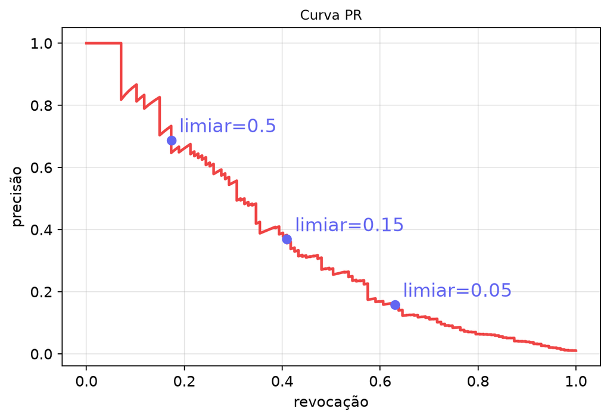

## Curva ROC

- Uma curva muito utilizada é a **curva ROC**, que plota a revocação contra a taxa de falso positivo (FP/(FP + VN)):
- Essa curva em geral **não é adequada para dados desbalanceados**, pois $FP<<VN$ e a taxa de falso positivo muda pouco.

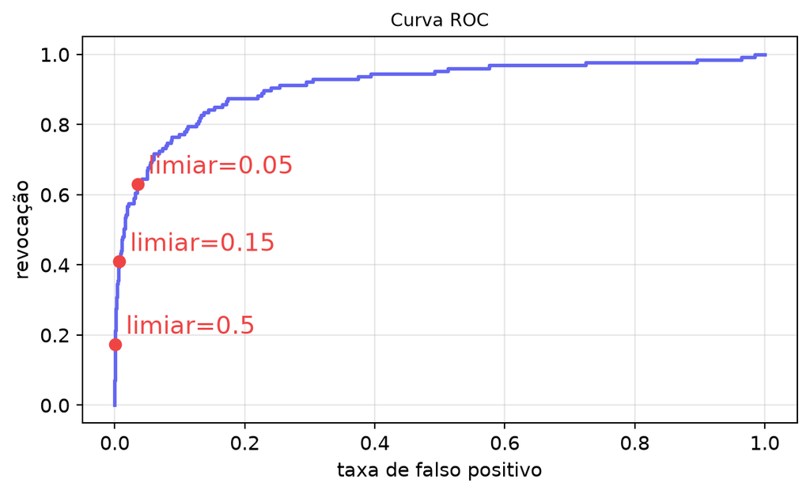

## Uma métrica para resumir a qualidade

- A área sob a curva é uma métrica que resume a qualidade do modelo em um único número.
- A **PR-AUC** resume a curva de precisão contra revocação.
- A **ROC-AUC** resume a curva de revocação contra taxa de falso positivo.

```python
from sklearn.metrics import average_precision_score, roc_auc_score

scores = model.predict_proba(X_test)[:, 1]
print(f"PR-AUC:  {average_precision_score(y_test, scores):.3f}")
print(f"ROC-AUC: {roc_auc_score(y_test, scores):.3f}")
```

```
PR-AUC:  0.363
ROC-AUC: 0.912
```

## Calibração de modelos

- Apesar do método do scikit-learn se chamar `predict_proba`, o score que ele devolve em geral **não é uma probabilidade**.
- É um erro muito comum assumir que `predict_proba` devolve uma probabilidade, o que pode levar a análises de risco/custo/decisão completamente **erradas**.
- Modelos que possuem `predict_proba` mas não devolvem probabilidades: árvores de decisão, Naive Bayes, k-vizinhos. Também regressão logística com alta regularização ou poucos dados.

## Calibração de modelos

- Dizemos que um score é **calibrado** quando ele representa ao menos uma aproximação de uma probabilidade.
- Por exemplo, suponha que um modelo gere o score 0.3 para 100 transações. Isso deve indicar que cada transação tem 30% de chance de ser fraudulenta.
- Utilizando o rótulo conhecido das transações (fraude ou não), verificamos que 50 delas eram realmente fraudes. Então o score 0.3 **não é calibrado**, pois ele deveria ter correspondido a 30 transações fraudulentas, e não 50.

## Calibração de modelos

- Para checar a calibração, dividimos os scores em faixas, como por exemplo [0, 0.2], [0.2, 0.4], [0.4, 0.6], [0.6, 0.8] e [0.8, 1.0].
- Para cada faixa, calculamos a **fração de fraudes** real e a **média dos scores** previstos pelo modelo.

## Calibração de modelos

- Exemplo de resultado:

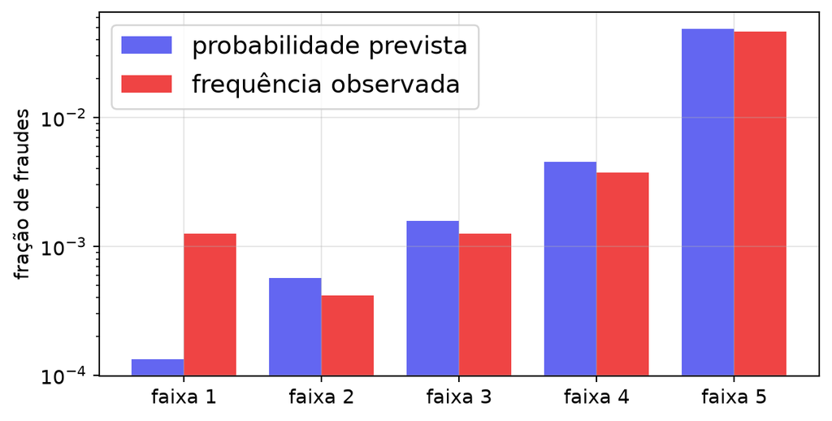

## Por que a calibração importa

- Decisões baseadas em custo esperado, preço de apólice ou limite de crédito precisam de probabilidade calibrada.
- O melhor modelo é aquele que não apenas possui boa classificação, mas que **também fornece probabilidades corretas**.
- Ex: Para um conjunto de clientes com taxa real de inadimplência de 60%, um modelo A prevê 0.9 e um modelo B prevê 0.6. Ambos podem classificar os clientes corretamente, mas o modelo A superestima o risco.

## Discriminação e calibração são coisas separadas

- **Discriminação** é a capacidade de ordenar: os positivos recebem scores maiores que os negativos. É o que PR-AUC e ROC-AUC medem.
- **Calibração** é a capacidade de acertar o valor: um score de $0.3$ corresponde a 30% de chance.
- Quando o modelo gera uma **fila de inspeção** (quais transações possuem maior chance de ser fraude?), só a discriminação importa. Quando ele alimenta uma **decisão**, a calibração passa a ser importante também.

## Brier score

- O **Brier score** é o erro quadrático médio entre o score previsto $\hat{p}_i \in [0, 1]$ e o rótulo $y_i \in \{0, 1\}$:

$$BS = \frac{1}{N}\sum_{i=1}^N (\hat{p}_i - y_i)^2$$

```python
from sklearn.metrics import brier_score_loss

print(f"Brier: {brier_score_loss(y_test, scores):.5f}")
```

```
Brier: 0.00819
```

- Ele é uma **regra estritamente própria de pontuação** que avalia conjuntamente calibração (confiabilidade) e discriminação (classificação).

# O limiar de decisão

## O mesmo modelo com quatro pontos de operação

- Podemos utilizar diferentes limiares para decidir se uma transação é fraude ou não:

```python
for cut in [0.5, 0.3, 0.15, 0.05]:
    flagged = (scores >= cut).astype(int)
    print(f"limiar {cut:<5} alarmes {flagged.sum():4d}"
          f"  precisão {precision_score(y_test, flagged):.3f}"
          f"  revocação {recall_score(y_test, flagged):.3f}")
```

```
limiar 0.5   alarmes   32  precisão 0.688  revocação 0.173
limiar 0.3   alarmes   67  precisão 0.552  revocação 0.291
limiar 0.15  alarmes  141  precisão 0.369  revocação 0.409
limiar 0.05  alarmes  506  precisão 0.158  revocação 0.630
```

- O que muda é a quantidade de alarmes que a equipe de análise precisa examinar.

## Decisão baseada em custos

- O limiar de decisão pode ser escolhido com base no **custo de errar**:

```python
# Custo de uma fraude não detectada, em reais
COST_FN = 500
# Custo de um alarme falso, em reais
COST_FP = 10

def total_cost(y_true, y_pred):
    """Custo total de um conjunto de decisões."""
    misses = ((y_true == 1) & (y_pred == 0)).sum()
    false_alarms = ((y_true == 0) & (y_pred == 1)).sum()
    return COST_FN*misses + COST_FP*false_alarms
```

## Decisão baseada em custos

```python
print(f"limiar 0,50: R${total_cost(y_test, scores >= 0.50)}")
print(f"limiar 0,05: R${total_cost(y_test, scores >= 0.05)}")
```

```
limiar 0,50: R$52600
limiar 0,05: R$27760
```

- O desbalanceamento afeta a **consequência de errar**. A diferença de tamanho entre as classes não é o problema, e é algo natural da aplicação.
- Os dois custos costumam vir da área de negócio. Muitas vezes só a razão entre eles precisa ser determinada.

## Custo em função do limiar

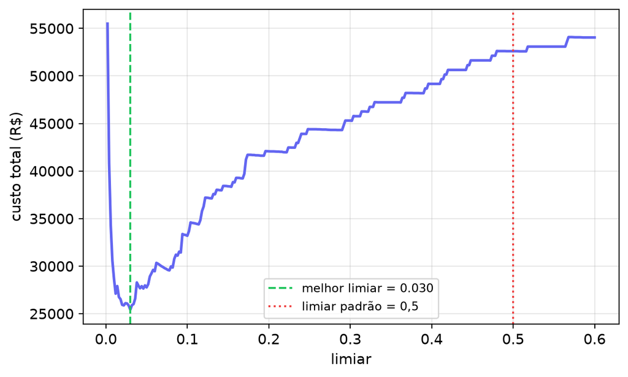

```
custo no limiar padrão: R$  52600
custo no melhor limiar: R$  25420
```

## Limiar definido pela capacidade

- Em muitos sistemas de triagem não existe matriz de custos, mas existe um limite de quantos casos podem ser investigados.
- Nesse caso o limiar é o quantil correspondente dos scores.

```python
# alarmes que a equipe consegue analisar por dia
capacity = 200

cut = np.quantile(scores, 1 - capacity/len(scores))
flagged = (scores >= cut).astype(int)

print(f"limiar pela capacidade: {cut:.3f}  alarmes: {flagged.sum()}")
print(f"precisão {precision_score(y_test, flagged):.3f}"
      f"  revocação {recall_score(y_test, flagged):.3f}")
```

```
limiar pela capacidade: 0.114  alarmes: 200
precisão 0.305  revocação 0.480
```

## O limiar é a primeira ferramenta em dados desbalanceados

- Não muda o modelo, então não exige retreino.
- Não muda a ordenação, então PR-AUC e ROC-AUC continuam iguais.
- Não muda a calibração, então decisões por custo continuam válidas.
- É modificado em produção com a alteração de uma constante.
- Boa parte do que se atribui ao desbalanceamento desaparece depois do ajuste.

# Ponderação da função de perda

## Ponderar a função de perda

- Outro procedimento comum em dados desbalanceados é dar mais peso aos erros na classe rara dentro da própria perda:

```python
LogisticRegression(class_weight="balanced")
RandomForestClassifier(class_weight="balanced")
```

- `"balanced"` usa $w_c = \frac{n}{k \cdot n_c}$, onde $n_c$ é o número de exemplos da classe $c$ e $k$ é o número de classes.
- Também é possível dar pesos diferentes para cada linha no momento do treinamento:

```python
model.fit(X, y, sample_weight=w)
```

## Peso a partir dos custos

- Os pesos também podem ser definidos pelos custos. Nesse caso, eles indicam quanto vale errar cada linha:

```python
# peso proporcional ao custo de errar cada linha
weights = np.where(y_train == 1, COST_FN, COST_FP)
model.fit(X, y, sample_weight=weights)
```

## Ponderação altera a calibração

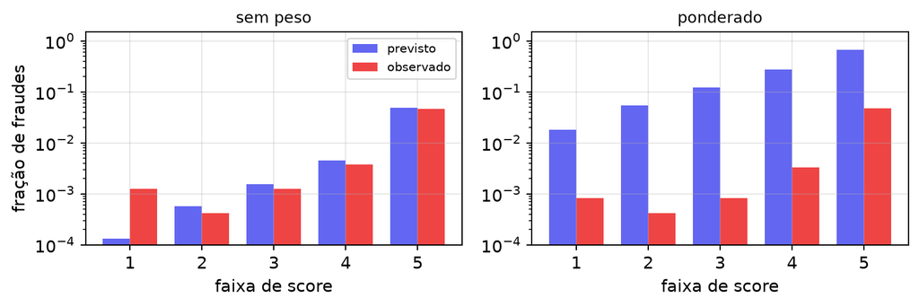

- Ponderar faz com que os scores deixem de ser probabilidades.
- É possível recalibrar o modelo usando a classe `CalibratedClassifierCV` do scikit-learn em um conjunto de validação.

## Limiar ou peso?

- Alguns métodos são nativamente ótimos sem ponderação. Regressão logística é um exemplo. Tais métodos em geral não são beneficiados por ponderação, ou podem até ser prejudicados por ela. **O foco deve ser no limiar**.
- Outros métodos, como florestas aleatórias, podem ignorar completamente a classe minoritária. **Nesses casos, ponderação é importante**.

# Reamostragem de dados

## Reamostrar é uma terceira opção em dados desbalanceados

- Reamostrar consiste em **descartar** exemplos da classe majoritária ou **gerar** exemplos da classe minoritária.
- Reamostragem era uma técnica muito popular, mas a literatura recente é crítica sobre essa técnica.
- Diversos estudos mostraram que o ganho de reamostrar é nulo para classificadores modernos com ajustes de limiar.
- Ainda assim, existem casos em que reamostrar é a única opção.

## A biblioteca `imbalanced-learn`

- A biblioteca `imbalanced-learn` possui diversos métodos de reamostragem.
- Ela segue a API do scikit-learn, e cada amostrador é um objeto com o método `fit_resample(X, y)`:

```python
X_resampled, y_resampled = sampler.fit_resample(X, y)
```

- `fit_resample` devolve um conjunto com **número de linhas diferente** do original.

## Subamostragem aleatória

```python
from imblearn.under_sampling import RandomUnderSampler

# sampling_strategy=0.1 significa 1 positivo para cada 10 negativos
under = RandomUnderSampler(sampling_strategy=0.1, random_state=0)
X_under, y_under = under.fit_resample(X_train, y_train)

print(f"antes:  {np.bincount(y_train)}")
print(f"depois: {np.bincount(y_under)}")
```

```
antes:  [27704   296]
depois: [2960  296]
```

- Em geral, igualar as classes é exagero, e ir de 1:100 para 1:10 já evita efeitos extremos de desbalanceamento.

## Superamostragem aleatória

```python
# cópias exatas de linhas
RandomOverSampler(random_state=0)
# cópias com ruído gaussiano
RandomOverSampler(random_state=0, shrinkage=0.3)
```

- Com `shrinkage`, cada cópia recebe um deslocamento aleatório proporcional ao desvio-padrão da coluna.

## SMOTE

- *Synthetic Minority Over-sampling Technique* é de longe o método mais popular de superamostragem.
- O algoritmo:
  1. sorteie um ponto $x$ da classe minoritária,
  2. encontre os $k$ vizinhos mais próximos de $x$ **dentro da mesma classe**,
  3. sorteie um desses vizinhos, $x_{\text{viz}}$,
  4. gere $x_{\text{novo}} = x + \lambda\,(x_{\text{viz}} - x)$, com $\lambda \sim U(0,1)$.
- O ponto novo cai em algum lugar do segmento entre dois exemplos reais da classe rara.

## Exemplo de SMOTE

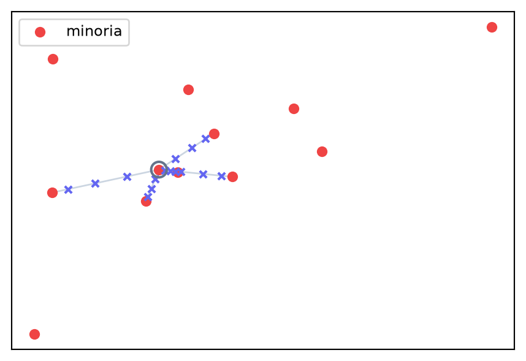

- Os `x` são pontos sintéticos possíveis entre o ponto de referência e seus vizinhos.

## A hipótese do SMOTE

- O SMOTE possui a hipótese: **o segmento entre dois exemplos vizinhos da mesma classe também pertence a essa classe.**
- Quando a hipótese é verdadeira, o SMOTE preenche buracos da amostra e melhora a estimativa de densidade da classe rara.
- Quando é falsa, o SMOTE fabrica exemplos que não existem, com o rótulo errado.

## Considerações sobre o SMOTE

- O SMOTE procura vizinhos com distância euclidiana, então é preciso escalonar os dados.
- A média entre “São Paulo” e “Recife” não existe. A versão `SMOTENC` interpola apenas as colunas contínuas e, nas categóricas, copia o valor mais frequente entre os vizinhos.
- Evite aplicar SMOTE depois de um `OneHotEncoder`. A interpolação produz valores como $0.37$ em colunas que só admitem 0 e 1.

## Variantes do SMOTE

| Variante | Pontos utilizados | Observação |
| --- | --- | --- |
| `SMOTE` | qualquer ponto da CMIN | - |
| `BorderlineSMOTE` | pontos da CMIN com vizinhos da CMAJ | concentra o esforço na fronteira |
| `ADASYN` | mais pontos onde a fronteira é mais difícil | densidade proporcional ao erro local |
| `KMeansSMOTE` | dentro de agrupamentos densos da CMIN | evita interpolar entre grupos separados |
| `SMOTEENN` | SMOTE + limpeza | remove pontos da CMIN que caíram na região da CMAJ |

- CMIN: classe minoritária, CMAJ: classe majoritária.

## Comparação entre os amostradores

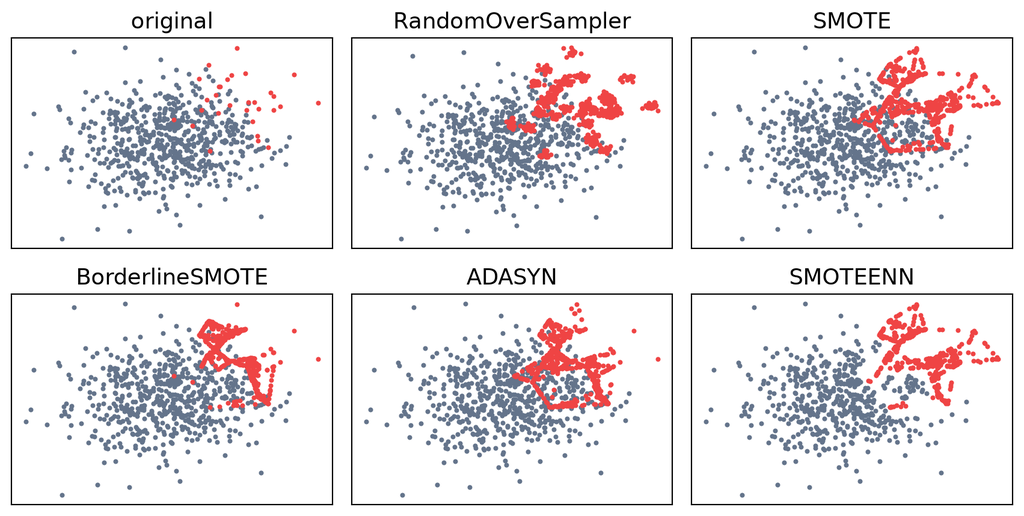

## Reamostragem apenas no treino

- **Reamostre apenas o conjunto de treino.** Nunca o teste ou a validação.
- A avaliação precisa acontecer na distribuição em que o modelo vai operar. Um teste balanceado é uma situação que não ocorre na prática, e portanto não é realista.
  - superamostrar o teste inventa exemplos e mede o modelo sobre a própria interpolação,
  - subamostrar o teste muda a taxa base e infla a precisão,
  - limpar o teste remove exatamente os casos difíceis.

# Casos que precisam de reamostragem

## Métodos que não permitem ponderação ou limiar

- Os métodos k-vizinhos, LDA, Naive Bayes a Perceptron do scikit-learn não permitem ponderação.
- Árvores de decisão simples, k-vizinhos e outros tendem a retornar scores difíceis ou mesmo impossíveis de calibrar.

## Etapas sem rótulo

- Boa parte de um pipeline acontece antes de existir uma função de perda:
  - clusterização usada como diagnóstico ou como atributo,
  - `KNNImputer`, que realiza imputação por distância,
  - busca por vizinhos e seleção de protótipos,
  - redução de dimensionalidade
- Todas essas etapas enxergam apenas a densidade dos pontos. Classes raras são ignoradas.
- Nesses casos, reamostragem pode ser útil.

## Seleção de instâncias contra ruído de rótulo

- Uma utilidade de subamostragem é **remover pontos que contradizem a vizinhança**.
- Dois métodos clássicos:
  - **Ligação de Tomek.** Dois pontos de classes diferentes que são o vizinho mais próximo um do outro. Um dos dois é removido.
  - **Edição de Wilson (ENN).** Remova o ponto se o rótulo dele discorda da maioria dos $k$ vizinhos.

## Exemplo de aplicação do ENN

- Pontos removidos pelo ENN estão indicados por círculos:

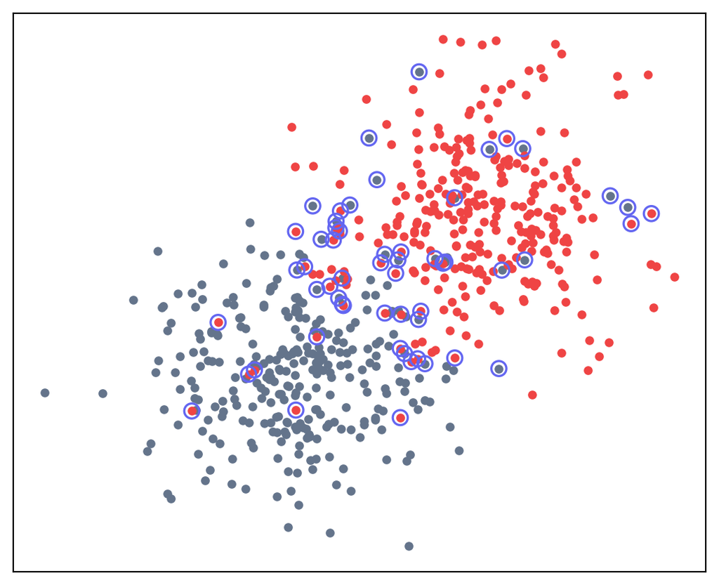

- A hipótese do ENN é que pontos de uma classe dentro da outra são **erros de anotação**.

## Roteiro para dados desbalanceados

| Situação | Ação recomendada |
| --- | --- |
| Primeira coisa a fazer | trocar a acurácia por PR-AUC |
| Os custos de errar são conhecidos | escolher o limiar que minimiza o custo esperado |
| A equipe tem capacidade limitada de análise | escolher o limiar pela capacidade |
| O modelo aceita peso e o limiar já foi ajustado | testar `class_weight` ou `sample_weight` |
| Suspeita de rótulo errado ou sobreposição | limpar com subamostragem |
| Etapa do pipeline sem rótulo | reamostrar, porque não há onde ponderar |
| Poucos positivos e a classe é multimodal | rotular mais dados, reformular o problema |